# My Movies

João Neto

September, 2026

This table includes movies I think have a higher than average quality in either plot, main themes and overall cinematography. I’ll keep inserting recent movies at the top of the table, and older movies at the end of the table.

The ratings go from $3$ to $10$ (so, eight different basic rates). Movies with $6$ are just below average, while movies with $7$ are just above average. A rating of $5$ means a bad movie, while $8$ is a good movie. A rating of $4$ is a very bad movie, while a $9$ is a great movie. There a just a few $3$ which are horrible movies, and a few $10$ which are perfect movies (imho).

Starting from rate $7$ I include quarter scores (like, $7.25$ or $8.75$) to distinguish and compare a bit better between movies. For me, a $9.5$ rating is already a masterpiece.

The next table shows 3328 movies with ratings 7+, it represents 56.2% of [all movies I’ve seen](https://www.imdb.com/user/ur3443219/ratings?ref_=nv_usr_rt_4) and is, obviously, quite subjective :-)

All 5917 rated movies are displayed at the end of this page.

|  | Title | Year | Decade | Country | Genre | Time | Rate | Imdb | Votes | Director | links |
| --- | --- | --- | --- | --- | --- | --- | --- | --- | --- | --- | --- |
| 1 | Rose | 2026 | 2020s | Austria | Drama | 94 | 8.25 | 7.6 | 1415 | Markus Schleinzer | 🎥🎬 |
| 2 | DC | 2026 | 2020s | India | Crime | 141 | 7.25 | 7.9 | 7428 | Arun Matheswaran | 🎥🎬 |
| 3 | The Odyssey | 2026 | 2020s | USA | Fantasy | 172 | 8.25 | 8.4 | 495176 | Christopher Nolan | 🎥🎬 |
| 4 | The Invite | 2026 | 2020s | USA | Comedy | 107 | 7 | 7.5 | 68408 | Olivia Wilde | 🎥🎬 |
| 5 | Ghost in the Cell | 2026 | 2020s | Indonesia | Horror | 106 | 7.5 | 6.7 | 3119 | Joko Anwar | 🎥🎬 |
| 6 | The Death of Robin Hood | 2026 | 2020s | USA | Drama | 122 | 8.75 | 6 | 19272 | Michael Sarnoski | 🎥🎬 |
| 7 | Leviticus | 2026 | 2020s | Australia | Horror | 88 | 7.25 | 6.4 | 17197 | Adrian Chiarella | 🎥🎬 |
| 8 | La Valle dei Sorrisi | 2025 | 2020s | Italy | Horror | 122 | 8 | 6.5 | 1804 | Paolo Strippoli | 🎥🎬 |
| 9 | The Furious | 2025 | 2020s | Hong Kong | Action | 113 | 7.25 | 7.2 | 26400 | Kenji Tanigaki | 🎥🎬 |
| 10 | Marama | 2025 | 2020s | New Zealand | Drama | 89 | 7 | 6 | 1813 | Taratoa Stappard | 🎥🎬 |

[output cut: 3318 more lines]

## Number of Selected Movies per Year

Showing movies with a minimal rating of 8 (blue) and the rest (orange). The list of movies from 1960-2023 is (somewhat) complete. My next goal is to move into the 1950s.

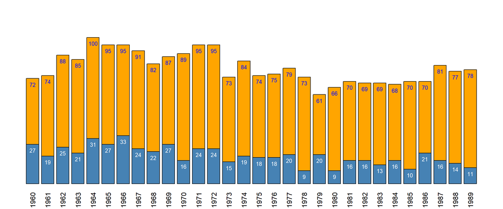

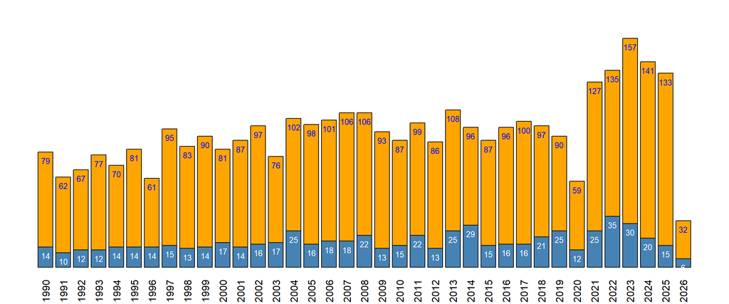

There are hundreds still to see from the 1920s to the 1950s, and these are the respective wish-lists:

- [wishlist from the 1920s](https://www.imdb.com/list/ls088146253/?pf_rd_m=A2FGELUUNOQJNL&pf_rd_p=4dc7ad1a-76a6-49eb-9acb-5d6959572df8&pf_rd_r=2N4WWMA2RBEP12AVJGS9&pf_rd_s=right-4&pf_rd_t=48201&pf_rd_i=watchlist&ref_=wt_otl_1)
- [wishlist from the 1930s](https://www.imdb.com/list/ls088107424/?pf_rd_m=A2FGELUUNOQJNL&pf_rd_p=4dc7ad1a-76a6-49eb-9acb-5d6959572df8&pf_rd_r=GJR77FD60TS77BB3BTM4&pf_rd_s=right-4&pf_rd_t=48201&pf_rd_i=watchlist&ref_=wt_otl_2)
- [wishlist from the 1940s](https://www.imdb.com/list/ls088795556/?pf_rd_m=A2FGELUUNOQJNL&pf_rd_p=4dc7ad1a-76a6-49eb-9acb-5d6959572df8&pf_rd_r=0FCARTR5AZ8DRVB27SH3&pf_rd_s=right-4&pf_rd_t=48201&pf_rd_i=watchlist&ref_=wt_otl_4)
- wishlist from the 1950s

There’s also some movies I was [unable to find](https://www.imdb.com/list/ls529885371).

## Total ranked movies

These numbers include all movies I ranked at IMDB:

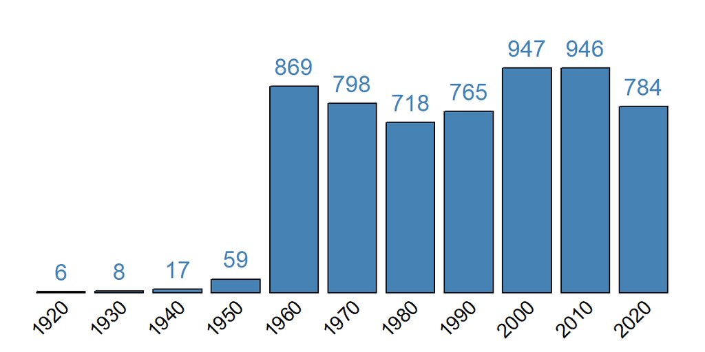

## Number of Selected Movies per Decade

Number of movies with a score of at least 7:

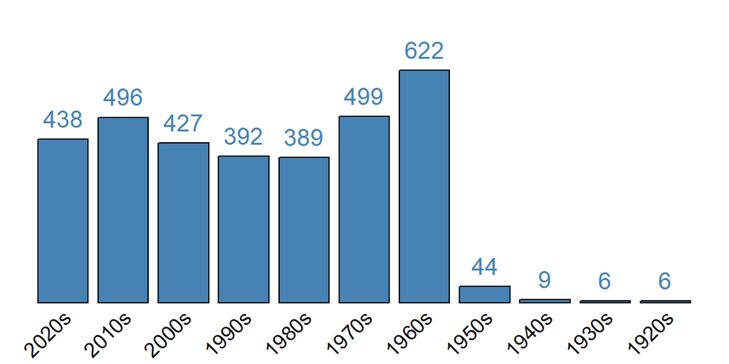

## Movie quality per Decade

Let’s see how many very good films (rating at least 8) each decade produced,

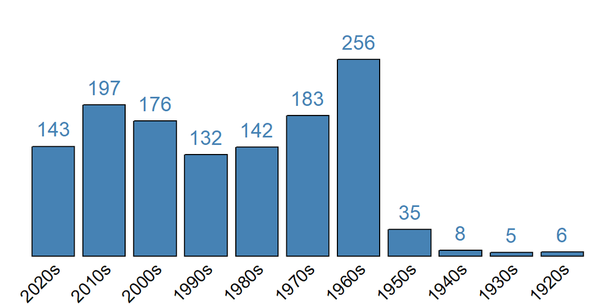

And how many great films (rating at least 9) per decade,

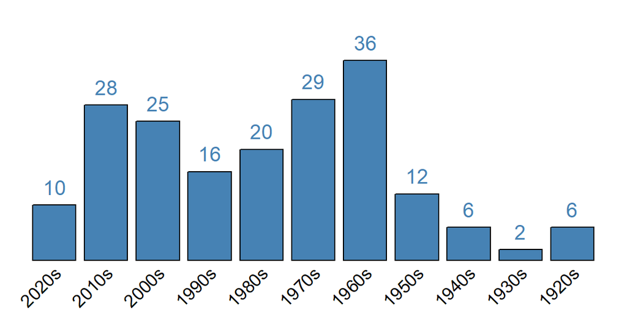

And masterpieces (rating of at least 9.5) per decade,

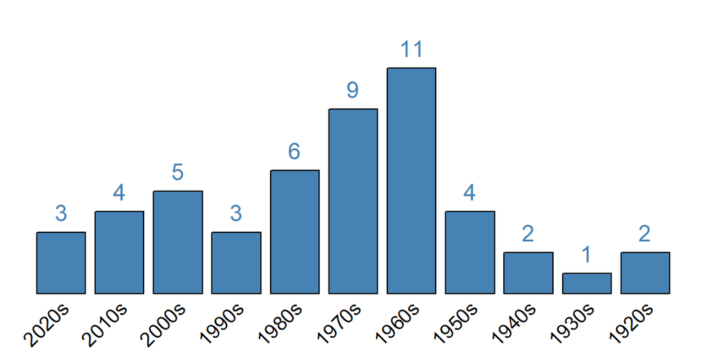

## Movies per Directors

Let’s check directors with multiple movies in the list,

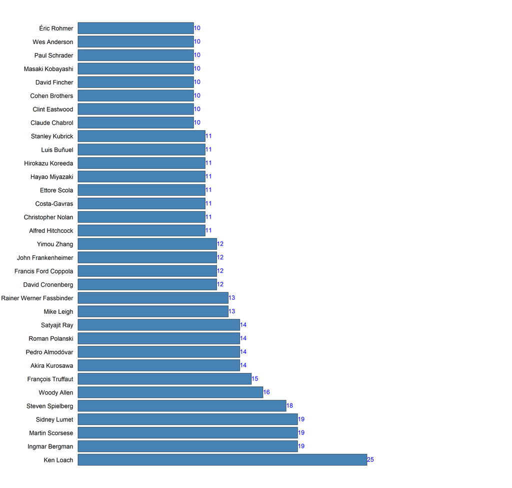

Directors with movies with a rating of at least 8.5,

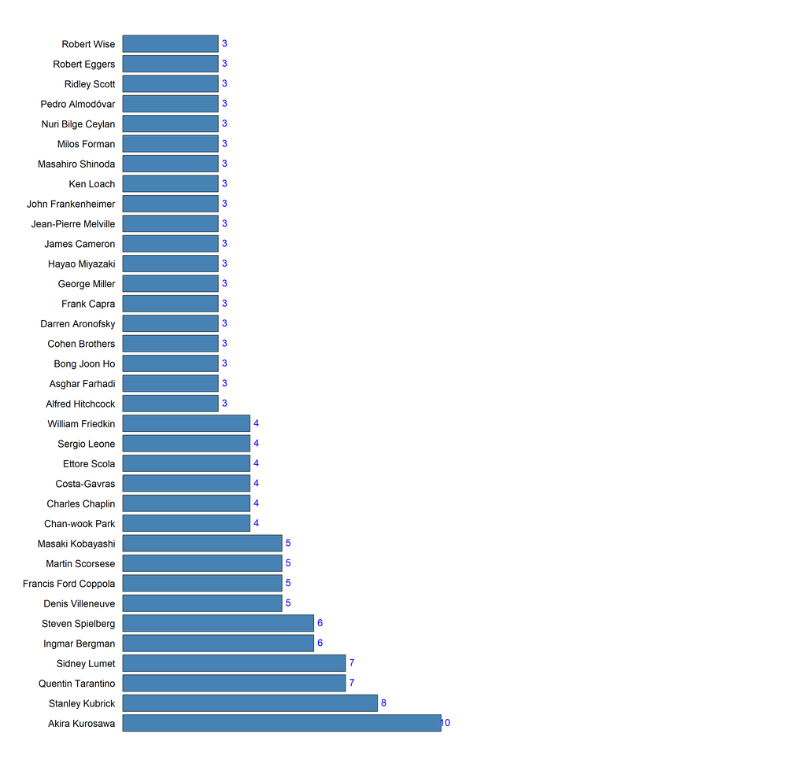

And, finally, who made the masterpieces (≥9.5),

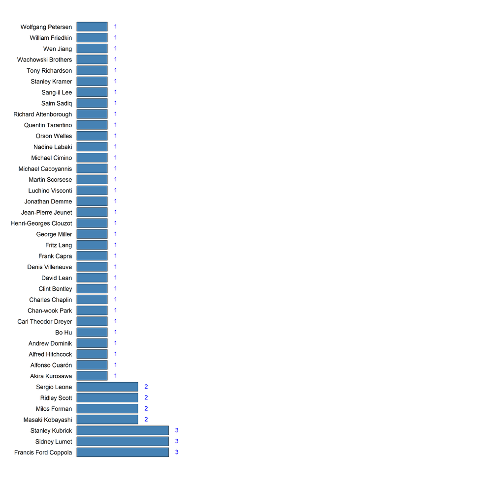

The next table sums, for each director, the scores of each film rated here. A film ranked 7 gets 1 point, 7.25 gets 2 points, upto a score 10 that gets 13 points. For the Imdb score, films with score less or equal to 6.5 get negative points.

|  | Director | Score | Imdb |
| --- | --- | --- | --- |
| 1 | Ingmar Bergman | 108 | 69 |
| 2 | Sidney Lumet | 105 | 49 |
| 3 | Akira Kurosawa | 99 | 72.4 |
| 4 | Ken Loach | 91 | 52.2 |
| 5 | Stanley Kubrick | 89 | 57.8 |
| 6 | Steven Spielberg | 89 | 72 |
| 7 | Martin Scorsese | 81 | 69 |
| 8 | Masaki Kobayashi | 70 | 50.4 |
| 9 | Denis Villeneuve | 67 | 39 |
| 10 | Quentin Tarantino | 67 | 49 |

[output cut: 1652 more lines]

The next table show these scores per decade and director.

|  | Director | Decade | Score | Imdb |
| --- | --- | --- | --- | --- |
| 1 | Ingmar Bergman | 1960s | 48 | 36.2 |
| 2 | John Frankenheimer | 1960s | 48 | 21.2 |
| 3 | Masaki Kobayashi | 1960s | 48 | 32 |
| 4 | Denis Villeneuve | 2010s | 44 | 25.6 |
| 5 | Francis Ford Coppola | 1970s | 44 | 29.2 |
| 6 | Jean-Pierre Melville | 1960s | 39 | 20.8 |
| 7 | Rainer Werner Fassbinder | 1970s | 39 | 27.6 |
| 8 | Akira Kurosawa | 1950s | 37 | 24 |
| 9 | Yimou Zhang | 1990s | 37 | 27 |
| 10 | Luis Buñuel | 1960s | 36 | 24.2 |

[output cut: 2310 more lines]

## Movies per Genre

The most represented genre is drama, an umbrella category for many different types of movie. The remaining genres are:

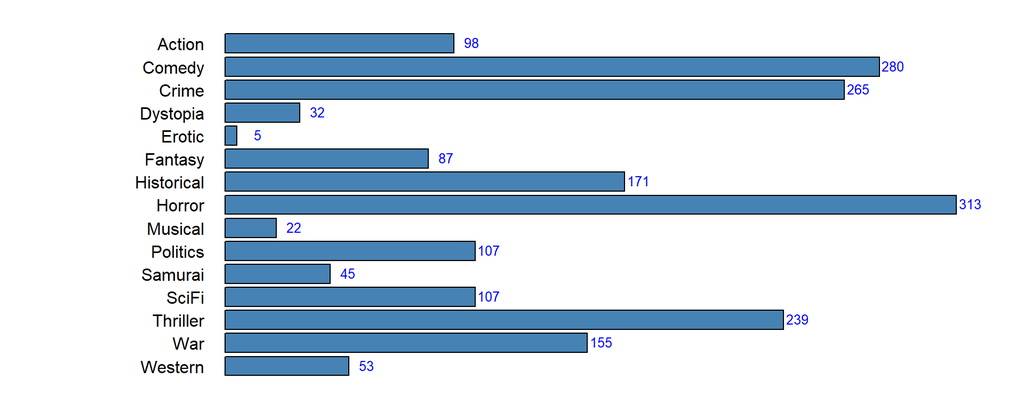

## Movies per Country

The next plot shows only movies with 7+ rating. Hollywood is highly represented with a current total of 1223 American movies. Let’s check how other countries are represented:

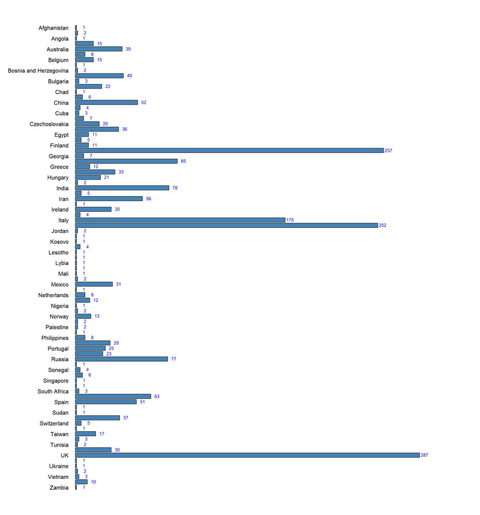

## All rated movies on Imdb

This table includes all movies I rated on Imdb, including those with less than a rate of 7. On imdb the only allowed rates are integers from 1 to 10.

|  | Title | Date | Genres | Time | Directors | Rate | Imdb | Votes | link |
| --- | --- | --- | --- | --- | --- | --- | --- | --- | --- |
| 1 | Police Python 357 | 1980-02 | Crime, Drama, Thriller | 126 | Alain Corneau | 7 | 6.9 | 2429 | 🎥 |
| 2 | The End of Oak Street | 2026-08-14 | Mystery, Thriller, Action, Adventure, Sci-Fi | 99 | David Robert Mitchell | 5 | 6.4 | 44759 | 🎥 |
| 3 | Rose | 2026-04-17 | Drama, History, Biography, War | 94 | Markus Schleinzer | 8 | 7.6 | 1415 | 🎥 |
| 4 | A Season in Hakkari | 1984-01-06 | Drama | 110 | Erden Kiral | 7 | 7.4 | 1836 | 🎥 |
| 5 | Under the Skin of the City | 2005-05-25 | Drama | 92 | Rakhshan Banietemad | 7 | 7.2 | 1795 | 🎥 |
| 6 | Sheep in the Box | 2026-07-31 | Drama, Sci-Fi, Fantasy | 126 | Hirokazu Koreeda | 6 | 6 | 913 | 🎥 |
| 7 | Mariken van Nieumeghen | 1975-12 | History, Drama | 80 | Jos Stelling | 6 | 6.3 | 286 | 🎥 |
| 8 | A Day in the Death of Joe Egg | 1972-06-04 | Drama, Comedy | 106 | Peter Medak | 7 | 6.8 | 644 | 🎥 |
| 9 | The Stationmaster's Wife | 1977-07-31 | Drama | 201 | Rainer Werner Fassbinder | 7 | 7 | 844 | 🎥 |
| 10 | DC | 2026-08-07 | Action, Drama, Romance, Crime, Thriller | 141 | Arun Matheswaran | 7 | 7.9 | 7428 | 🎥 |

[output cut: 5907 more lines]

**Quick movie search at IMDB**

genres: (e.g., horror,sci-fi,!animation,!documentary)  
min rating:  
min votes:  
date: from to  
[countries:](https://help.imdb.com/article/contribution/other-submission-guides/country-codes/G99K4LFRMSC37DCN#) [language:](https://www.loc.gov/standards/iso639-2/php/code_list.php)  
keywords: (e.g., superhero,!marvel)  
just my movies:  
not my movies:  
[[advanced search](https://www.imdb.com/search/title/)]

[next films in Portugal](https://www.imdb.com/calendar/?ref_=rlm&region=PT&type=MOVIE)